# Fat FACS Notebook

Enter the directory of the maca folder on your drive and the name of the tissue you want to analyze.

```r
tissue_of_interest = "Fat"
```

Load the requisite packages and some additional helper functions.

```r
library(here)
library(useful)
library(Seurat)
library(dplyr)
library(Matrix)

save_dir = here('00_data_ingest', 'tissue_robj')
```

```r
# read the metadata to get the plates we want
plate_metadata_filename = here('00_data_ingest', 'facs_raw_data', 'metadata_FACS.csv')

plate_metadata <- read.csv(plate_metadata_filename, sep=",", header = TRUE)
colnames(plate_metadata)[1] <- "plate.barcode"
plate_metadata
```

```
##     plate.barcode      mouse.id          tissue           subtissue
## 1         D041914         3_8_M         Bladder                <NA>
## 2         D042253         3_9_M         Bladder                <NA>
## 3       MAA000487        3_10_M         Bladder                <NA>
## 4         B000610        3_56_F         Bladder                <NA>
## 5         B002764        3_38_F         Bladder                <NA>
## 6         B002771        3_39_F         Bladder                <NA>
## 7       MAA000538         3_8_M   Brain_Neurons          Cerebellum
## 8       MAA000550        3_10_M   Brain_Neurons         Hippocampus
## 9       MAA000553        3_10_M   Brain_Neurons         Hippocampus
## 10      MAA000560        3_10_M   Brain_Neurons              Cortex
## 11      MAA000561        3_10_M   Brain_Neurons              Cortex
## 12      MAA000563        3_10_M   Brain_Neurons         Hippocampus
## 13      MAA000564        3_10_M   Brain_Neurons            Striatum
## 14      MAA000570         3_8_M Brain_Microglia          Cerebellum
```

[output cut: 481 more lines]

Subset the metadata on the tissue.

```r
tissue_plates = filter(plate_metadata, tissue == tissue_of_interest)[,c('plate.barcode','tissue','subtissue','mouse.sex')]
tissue_plates
```

```
##    plate.barcode tissue subtissue mouse.sex
## 1      MAA000385    Fat      SCAT         M
## 2      MAA000386    Fat      SCAT         M
## 3      MAA000388    Fat       GAT         M
## 4      MAA000439    Fat       GAT         M
## 5      MAA000441    Fat       BAT         M
## 6      MAA000442    Fat       BAT         M
## 7      MAA000510    Fat      SCAT         M
## 8      MAA000554    Fat       GAT         M
## 9      MAA000556    Fat       BAT         M
## 10     MAA000599    Fat       BAT         M
## 11     MAA000873    Fat       MAT         M
## 12     MAA000877    Fat       MAT         M
## 13     MAA000913    Fat       GAT         M
## 14     MAA000914    Fat       MAT         M
## 15     MAA000934    Fat      SCAT         M
## 16     MAA000531    Fat       MAT         M
## 17       D043520    Fat       MAT         F
## 18       D043526    Fat      SCAT         F
## 19       D045058    Fat       GAT         F
## 20       D045064    Fat       MAT         F
## 21       D045067    Fat       GAT         F
## 22       B000127    Fat      SCAT         F
## 23       B001216    Fat       BAT         F
## 24       B002707    Fat       BAT         F
## 25       B001960    Fat       BAT         F
## 26       B002314    Fat       MAT         F
## 27       B002954    Fat      SCAT         F
## 28       B002955    Fat       GAT         F
```

Load the read count data.

```r
#Load the gene names and set the metadata columns by opening the first file
filename = here('00_data_ingest', 'facs_raw_data', 'FACS', paste0(tissue_of_interest, '-counts.csv'))

raw.data = read.csv(filename, sep=",", row.names=1)
# raw.data = data.frame(row.names = rownames(raw.data))
corner(raw.data)
```

```
##               B15.MAA000385.3_10_M.1.1 D15.MAA000385.3_10_M.1.1
## 0610005C13Rik                        0                        0
## 0610007C21Rik                       13                        0
## 0610007L01Rik                       70                        0
## 0610007N19Rik                        1                        0
## 0610007P08Rik                        0                        0
##               F15.MAA000385.3_10_M.1.1 L15.MAA000385.3_10_M.1.1
## 0610005C13Rik                        0                        0
## 0610007C21Rik                        0                        0
## 0610007L01Rik                        0                        0
## 0610007N19Rik                        0                        0
## 0610007P08Rik                        0                        0
##               O4.MAA000385.3_10_M.1.1
## 0610005C13Rik                       0
## 0610007C21Rik                       0
## 0610007L01Rik                       4
## 0610007N19Rik                       0
## 0610007P08Rik                       0
```

Make a vector of plate barcodes for each cell

```r
plate.barcodes = lapply(colnames(raw.data), function(x) strsplit(strsplit(x, "_")[[1]][1], '.', fixed=TRUE)[[1]][2])
head(plate.barcodes)
```

```
## [[1]]
## [1] "MAA000385"
##
## [[2]]
## [1] "MAA000385"
##
## [[3]]
## [1] "MAA000385"
##
## [[4]]
## [1] "MAA000385"
##
## [[5]]
## [1] "MAA000385"
##
## [[6]]
## [1] "MAA000385"
```

```r
barcode.df = t.data.frame(as.data.frame(plate.barcodes))

rownames(barcode.df) = colnames(raw.data)
colnames(barcode.df) = c('plate.barcode')
head(barcode.df)
```

```
##                          plate.barcode
## B15.MAA000385.3_10_M.1.1 "MAA000385"
## D15.MAA000385.3_10_M.1.1 "MAA000385"
## F15.MAA000385.3_10_M.1.1 "MAA000385"
## L15.MAA000385.3_10_M.1.1 "MAA000385"
## O4.MAA000385.3_10_M.1.1  "MAA000385"
## P16.MAA000385.3_10_M.1.1 "MAA000385"
```

```r
rnames = row.names(barcode.df)
meta.data <- merge(barcode.df, plate_metadata, by='plate.barcode', sort = F)
row.names(meta.data) <- rnames

# Sort cells by plate barcode because that's how the data was originally
meta.data = meta.data[order(meta.data$plate.barcode), ]
corner(meta.data)
```

```
##                        plate.barcode mouse.id tissue subtissue
## B2.B000127.3_38_F.1.1        B000127   3_38_F    Fat      SCAT
## K22.B000127.3_38_F.1.1       B000127   3_38_F    Fat      SCAT
## M2.B000127.3_38_F.1.1        B000127   3_38_F    Fat      SCAT
## N5.B000127.3_38_F.1.1        B000127   3_38_F    Fat      SCAT
## O7.B000127.3_38_F.1.1        B000127   3_38_F    Fat      SCAT
##                        FACS.selection
## B2.B000127.3_38_F.1.1        Multiple
## K22.B000127.3_38_F.1.1       Multiple
## M2.B000127.3_38_F.1.1        Multiple
## N5.B000127.3_38_F.1.1        Multiple
## O7.B000127.3_38_F.1.1        Multiple
```

```r
raw.data = raw.data[, rownames(meta.data)]
corner(raw.data)
```

```
##               B2.B000127.3_38_F.1.1 K22.B000127.3_38_F.1.1
## 0610005C13Rik                     0                      0
## 0610007C21Rik                     0                      0
## 0610007L01Rik                     0                      0
## 0610007N19Rik                     0                      0
## 0610007P08Rik                     0                      0
##               M2.B000127.3_38_F.1.1 N5.B000127.3_38_F.1.1
## 0610005C13Rik                     0                     0
## 0610007C21Rik                     0                     0
## 0610007L01Rik                     0                     0
## 0610007N19Rik                     0                     0
## 0610007P08Rik                     0                     0
##               O7.B000127.3_38_F.1.1
## 0610005C13Rik                     0
## 0610007C21Rik                   487
## 0610007L01Rik                     0
## 0610007N19Rik                     0
## 0610007P08Rik                     0
```

Process the raw data and load it into the Seurat object.

```r
# Find ERCC's, compute the percent ERCC, and drop them from the raw data.
erccs <- grep(pattern = "^ERCC-", x = rownames(x = raw.data), value = TRUE)
percent.ercc <- Matrix::colSums(raw.data[erccs, ])/Matrix::colSums(raw.data)
ercc.index <- grep(pattern = "^ERCC-", x = rownames(x = raw.data), value = FALSE)
raw.data <- raw.data[-ercc.index,]

# Create the Seurat object with all the data
tiss <- CreateSeuratObject(raw.data = raw.data, project = tissue_of_interest,
                    min.cells = 5, min.genes = 5)

tiss <- AddMetaData(object = tiss, meta.data)
tiss <- AddMetaData(object = tiss, percent.ercc, col.name = "percent.ercc")
# Change default name for sums of counts from nUMI to nReads
colnames(tiss@meta.data)[colnames(tiss@meta.data) == 'nUMI'] <- 'nReads'

# Create metadata columns for annotations and subannotations
tiss@meta.data[,'annotation'] <- NA
tiss@meta.data[,'subannotation'] <- NA
```

Calculate percent ribosomal genes.

```r
ribo.genes <- grep(pattern = "^Rp[sl][[:digit:]]", x = rownames(x = tiss@data), value = TRUE)
percent.ribo <- Matrix::colSums(tiss@raw.data[ribo.genes, ])/Matrix::colSums(tiss@raw.data)
tiss <- AddMetaData(object = tiss, metadata = percent.ribo, col.name = "percent.ribo")
```

A sanity check: genes per cell vs reads per cell.

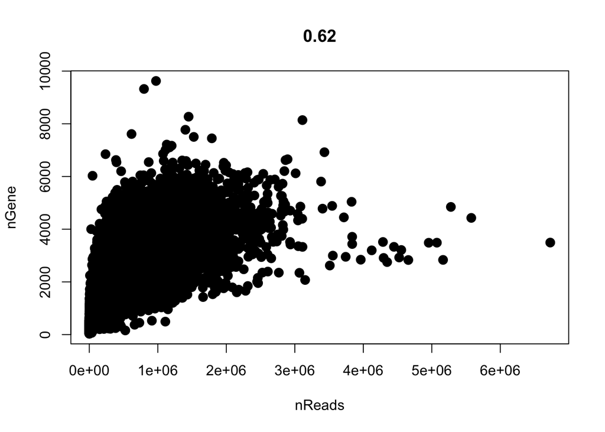

```r
GenePlot(object = tiss, gene1 = "nReads", gene2 = "nGene", use.raw=T)
```

Filter out cells with few reads and few genes.

```r
tiss <- FilterCells(object = tiss, subset.names = c("nGene", "nReads"),
    low.thresholds = c(500, 50000), high.thresholds = c(25000, 2000000))
```

Normalize the data, then regress out correlation with total reads

```r
tiss <- NormalizeData(object = tiss)
tiss <- ScaleData(object = tiss, vars.to.regress = c("nReads", "percent.ribo","Rn45s"))
```

```
## [1] "Regressing out nReads"       "Regressing out percent.ribo"
## [3] "Regressing out Rn45s"
##
## [1] "Scaling data matrix"
##
```

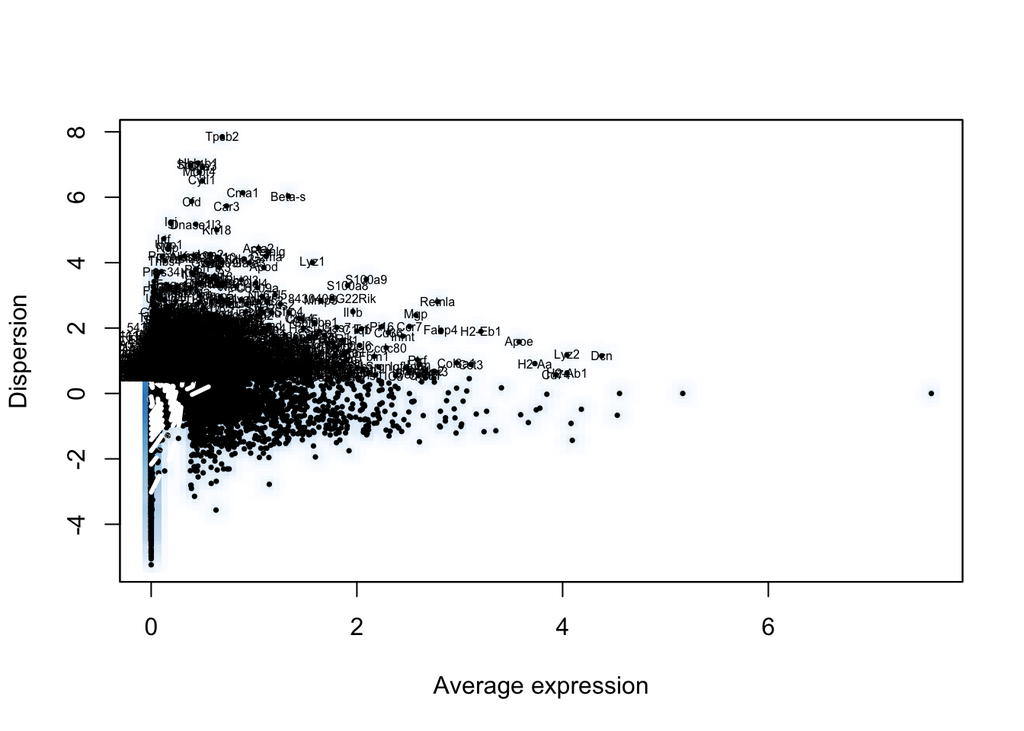

```r
tiss <- FindVariableGenes(object = tiss, do.plot = TRUE, x.high.cutoff = Inf, y.cutoff = 0.5)
```

Run Principal Component Analysis.

```r
tiss <- RunPCA(object = tiss, do.print = FALSE)
tiss <- ProjectPCA(object = tiss, do.print = FALSE)
```

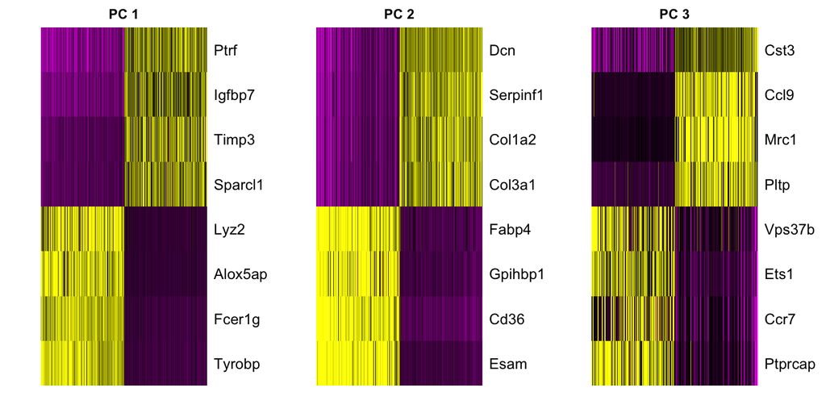

Later on (in FindClusters and TSNE) you will pick a number of principal components to use. This has the effect of keeping the major directions of variation in the data and, ideally, supressing noise. There is no correct answer to the number to use, but a decent rule of thumb is to go until the plot plateaus.

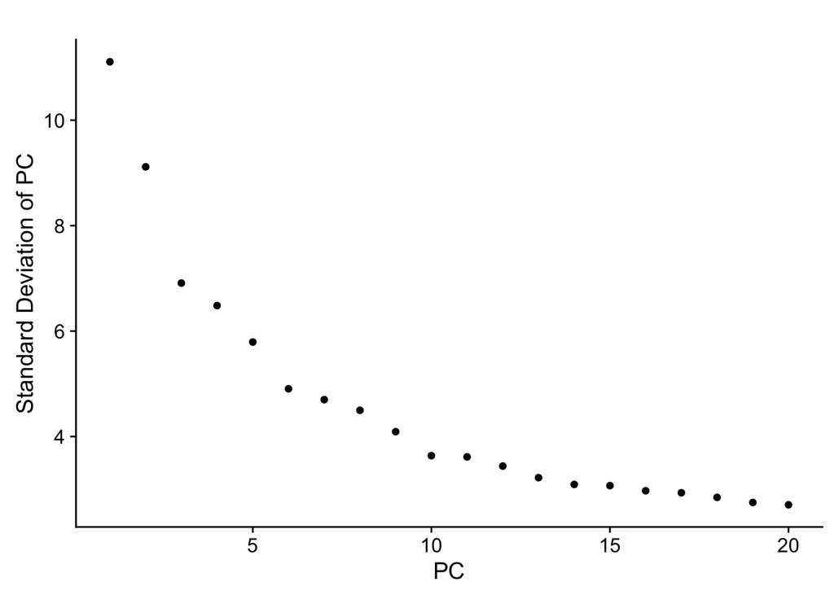

```r
PCElbowPlot(object = tiss)
```

Choose the number of principal components to use.

```r
# Set number of principal components.
n.pcs = 20
```

The clustering is performed based on a nearest neighbors graph. Cells that have similar expression will be joined together. The Louvain algorithm looks for groups of cells with high modularity–more connections within the group than between groups. The resolution parameter determines the scale…higher resolution will give more clusters, lower resolution will give fewer.

For the top-level clustering, aim to under-cluster instead of over-cluster. It will be easy to subset groups and further analyze them below.

```r
# Set resolution
res.used <- 0.5

tiss <- FindClusters(object = tiss, reduction.type = "pca", dims.use = 1:n.pcs,
    resolution = res.used, print.output = 0, save.SNN = TRUE)
```

To visualize

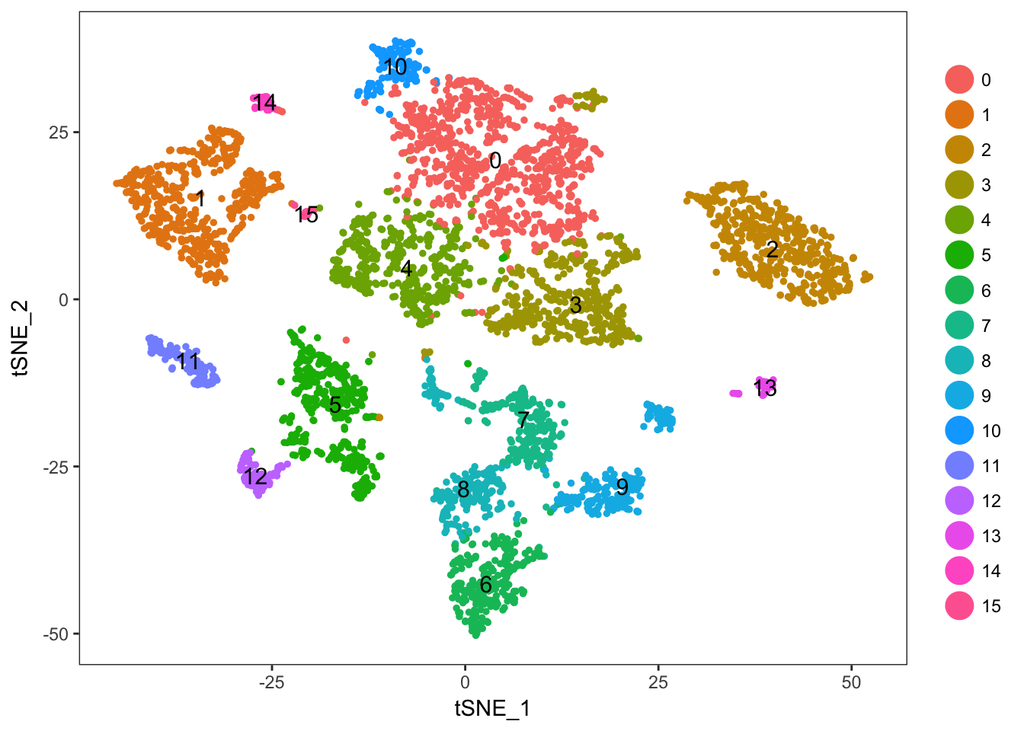

```r
# If cells are too spread out, you can raise the perplexity. If you have few cells, try a lower perplexity (but never less than 10).
tiss <- RunTSNE(object = tiss, dims.use = 1:n.pcs, seed.use = 10, perplexity=30)
TSNEPlot(object = tiss, do.label = T, dark.theme = F, pt.size = 1)
```

Check expression of genes of interset.

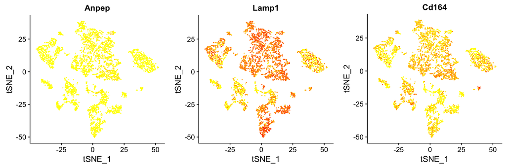

Dotplots let you see the intensity of exppression and the fraction of cells expressing for each of your genes of interest.

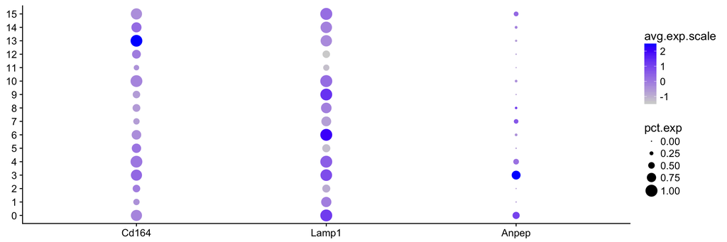

How big are the clusters?

```r
table(tiss@ident)
```

```
##
##   0   1   2   3   4   5   6   7   8   9  10  11  12  13  14  15
## 849 549 515 484 450 406 280 251 227 221 138 129  92  51  40  27
```

Which markers identify a specific cluster?

```r
clust.markers <- FindMarkers(object = tiss, ident.1 = 10, only.pos = TRUE, min.pct = 0.25, thresh.use = 0.25)
```

```r
print(x = head(x= clust.markers, n = 50))
```

```
##                  p_val  avg_diff pct.1 pct.2
## Olfml3   1.136753e-186 2.6953679 1.000 0.436
## Chrdl1   1.575709e-156 2.4566646 0.957 0.156
## Rbbp7    8.382207e-148 2.1344970 1.000 0.631
## Lbp      2.199574e-128 2.1074469 0.993 0.309
## Col4a4   3.030512e-127 1.2776625 0.877 0.101
## Mgp      8.760700e-125 2.1804963 1.000 0.510
## Col4a3   8.602172e-124 1.2134610 0.833 0.078
## Cpe      1.052024e-122 1.7324841 0.971 0.238
## Serping1 1.792379e-120 1.2327917 1.000 0.570
## Sfrp1    3.990970e-118 1.9476342 0.957 0.245
## Susd2    5.117813e-118 1.4802500 0.935 0.127
## C7       1.127471e-117 2.2171453 0.993 0.221
## Matn2    6.174956e-117 2.0233418 0.971 0.230
## Csrp1    2.640864e-114 1.5153531 1.000 0.452
## Boc      2.408727e-111 1.2319036 0.971 0.217
## Itgbl1   1.229786e-108 1.6699881 0.928 0.129
## Egflam   3.858835e-104 1.0567297 0.884 0.102
## Dcn      8.978916e-104 0.6125841 1.000 0.791
## Tspan11  1.160244e-102 1.0483806 0.920 0.115
## Nr2f2     2.466205e-99 1.1096456 0.993 0.313
## Smoc2     4.505918e-97 1.8072221 0.964 0.328
## Acsbg1    4.953917e-96 1.4701436 0.659 0.038
## Bgn       3.692326e-95 1.3607751 1.000 0.430
## Fmod      1.965775e-94 1.9709229 0.732 0.061
## Bace2     3.000517e-94 1.2608117 0.906 0.154
## Lamb2     1.300517e-92 1.3752604 1.000 0.407
## Arx       2.987176e-91 0.4895123 0.659 0.031
## Igf1      3.080854e-89 1.6478588 0.993 0.403
## Angpt4    1.476478e-87 1.5092387 0.638 0.039
## Cilp      3.178618e-87 2.3261248 0.790 0.129
## Aldh1a1   2.363651e-86 1.3151973 0.978 0.299
## Plcxd3    4.233214e-86 0.9301130 0.761 0.067
## Wfdc1     4.966564e-86 1.3946015 0.855 0.133
## Gpr64     1.600556e-85 0.7612779 0.804 0.096
## Mfap4     8.651184e-84 2.1407517 0.848 0.175
## Sorcs2    1.701839e-81 0.4090761 0.580 0.024
## Slit3     1.016008e-79 1.2246837 0.971 0.365
## Inhba     1.597813e-79 0.6352269 0.522 0.017
## Cygb      7.961688e-79 1.2346757 0.993 0.354
## Wnt6      9.414748e-79 0.6148472 0.486 0.013
## Gsn       3.017849e-78 0.7946837 1.000 0.932
## Paqr6     8.482970e-78 0.5026013 0.616 0.034
## Ntrk1     2.540027e-77 0.7636431 0.667 0.049
## Cfh       1.408994e-75 1.7473493 0.949 0.445
## Tcf21     2.542650e-75 0.5869870 0.855 0.178
## Tgfb2     1.568944e-74 0.9289452 0.862 0.164
## Ednra     3.552350e-73 0.6594550 0.645 0.063
## Gas1      4.722164e-73 1.4759414 1.000 0.397
## Cpxm2     6.077725e-73 1.5313653 0.638 0.068
## Des       1.322274e-72 0.8218800 0.775 0.102
```

You can also compute all markers for all clusters at once. This may take some time.

```r
tiss.markers <- FindAllMarkers(object = tiss, only.pos = TRUE, min.pct = 0.25, thresh.use = 0.25)
```

Display the top markers you computed above.

```r
tiss.markers %>% group_by(cluster) %>% top_n(5, avg_diff)
```

```
## # A tibble: 80 x 6
## # Groups:   cluster [16]
##            p_val avg_diff pct.1 pct.2 cluster          gene
##            <dbl>    <dbl> <dbl> <dbl>  <fctr>         <chr>
##  1  0.000000e+00 2.419430 0.972 0.352       0         Fbln1
##  2  0.000000e+00 2.136766 0.886 0.281       0          Inmt
##  3  0.000000e+00 1.978203 0.842 0.170       0            F3
##  4  0.000000e+00 1.949338 0.934 0.434       0           Mgp
##  5 1.981727e-226 1.716661 0.754 0.250       0         Spon2
##  6  0.000000e+00 4.359202 0.978 0.242       1         Fabp4
##  7  0.000000e+00 3.648497 0.827 0.080       1 8430408G22Rik
##  8  0.000000e+00 3.471599 0.967 0.285       1          Cd36
##  9  0.000000e+00 3.464513 0.893 0.058       1       Gpihbp1
## 10  0.000000e+00 3.162226 0.934 0.072       1          Esam
## # ... with 70 more rows
```

## Assigning cell type identity to clusters

At a coarse level, we can use canonical markers to match the unbiased clustering to known cell types:

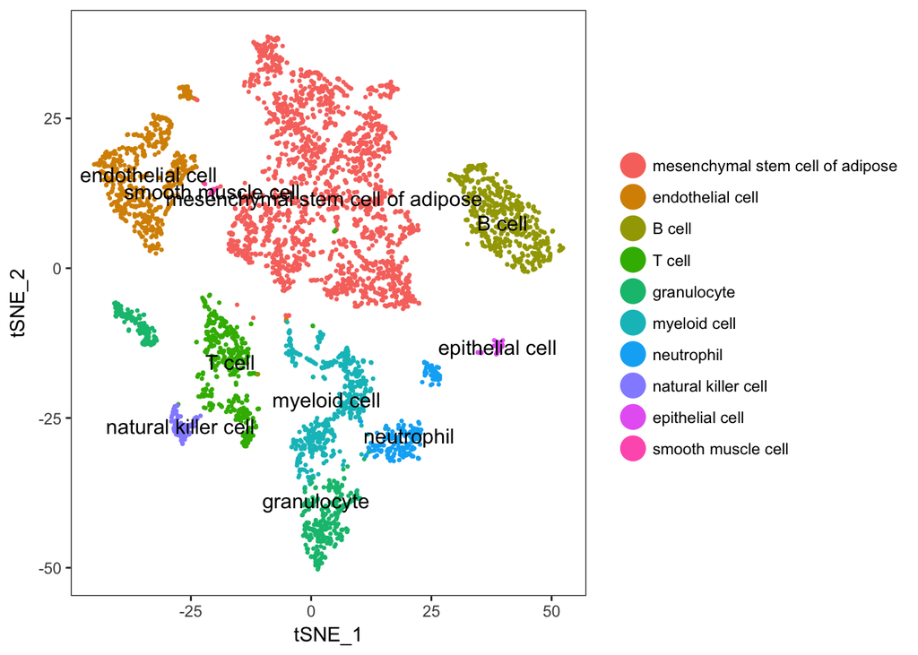

```r
# stash current cluster IDs
tiss <- StashIdent(object = tiss, save.name = "cluster.ids")

# enumerate current cluster IDs and the labels for them
cluster.ids <- c(0, 1, 2, 3, 4, 5, 6, 7, 8, 9, 10, 11, 12, 13, 14, 15)
annotation <-
  c(
  "mesenchymal stem cell of adipose",
  "endothelial cell",
  "B cell",
  "mesenchymal stem cell of adipose",
  "mesenchymal stem cell of adipose",
  "T cell",
  "granulocyte",
  "myeloid cell",
  "myeloid cell",
  "neutrophil",
  "mesenchymal stem cell of adipose",
  "granulocyte",
  "natural killer cell",
  "epithelial cell",
  "endothelial cell",
  "smooth muscle cell"
  )
cell_ontology_id <-
  c(
  "CL:0002570",
  "CL:0000115",
  "CL:0000236",
  "CL:0002570",
  "CL:0002570",
  "CL:0000084",
  "CL:0000094",
  "CL:0000763",
  "CL:0000763",
  "CL:0000775",
  "CL:0002570",
  "CL:0000094",
  "CL:0000623",
  "CL:0000066",
  "CL:0000115",
  "CL:0000192"
  )


tiss@meta.data[,'annotation'] <- plyr::mapvalues(x = tiss@ident, from = cluster.ids, to = annotation)
tiss@meta.data[,'cell_ontology_id'] <- plyr::mapvalues(x = tiss@ident, from = cluster.ids, to = cell_ontology_id)

tiss@meta.data[tiss@cell.names,'annotation'] <- as.character(tiss@meta.data$annotation)
tiss@meta.data[tiss@cell.names,'cell_ontology_id'] <- as.character(tiss@meta.data$cell_ontology_id)

TSNEPlot(object = tiss, do.label = TRUE, pt.size = 0.5, group.by='annotation')
```

## Checking for batch effects

Color by metadata, like plate barcode, to check for batch effects.

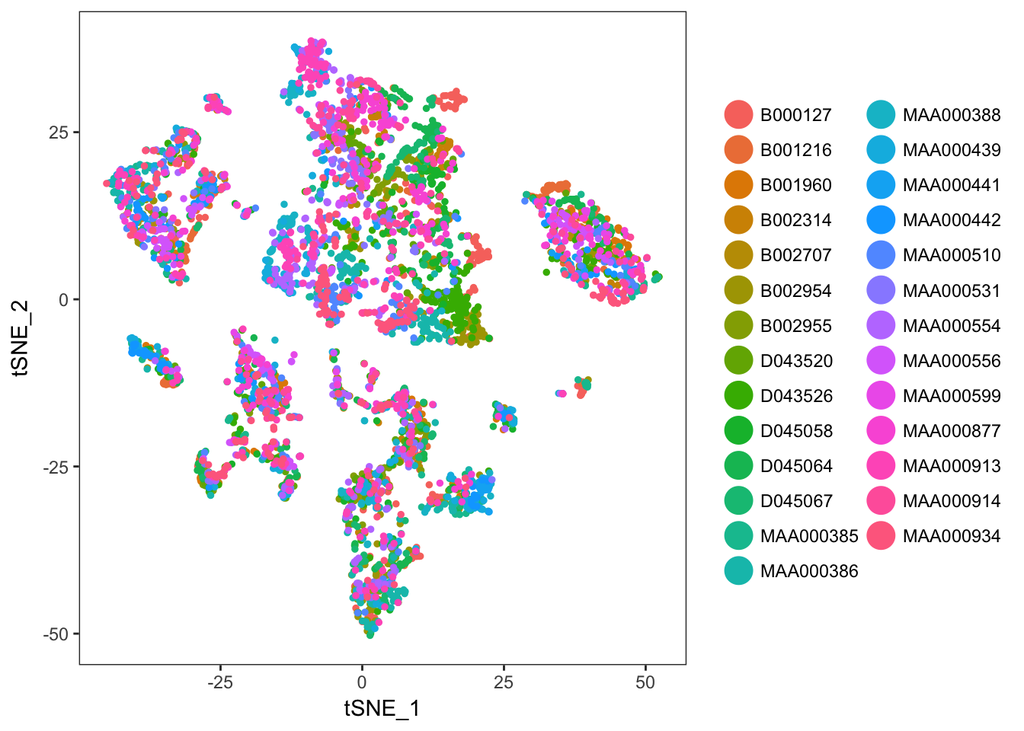

```r
TSNEPlot(object = tiss, do.return = TRUE, group.by = "plate.barcode")
```

Print a table showing the count of cells in each identity category from each plate.

```r
table(as.character(tiss@ident), as.character(tiss@meta.data$plate.barcode))
```

```
##
##      B000127 B001216 B001960 B002314 B002707 B002954 B002955 D043520
##   0       29       8       0      78      12      20      56      64
##   1       58      21      16      17       8      34       7       4
##   10       0       0       0       0       0       0       0       0
##   11       2      15       8       3       5       2       1       3
##   12       6       2       5       6       4       1       9       8
##   13      27       1       0       0       0       1       0       0
##   14       0       0       0       2       0       0       0       0
##   15       2       0       0       0       0       1       0       0
##   2        4      46      38      14      20       2      13       7
##   3       72       0       0       3       3      74      12       7
##   4        5       0       0       0       0      16       1       2
##   5        9       8      15      34       4       6      13      12
##   6       34       1       0       7       1      38      18       8
```

[output cut: 57 more lines]

# Save the Robject for later

When you save the annotated tissue, please give it a name.

```r
filename = here('00_data_ingest', 'tissue_seurat_robj',
                     paste0(tissue_of_interest, "_seurat_tiss.Robj"))
print(filename)
```

```
## [1] "/Users/olgabot/code/tabula-muris/00_data_ingest/tissue_seurat_robj/Fat_seurat_tiss.Robj"
```

```r
save(tiss, file=filename)
```

# Export the final metadata

So that Biohub can easily combine all your annotations, please export them as a simple csv.

```r
head(tiss@meta.data)
```

```
##                        nGene  nReads orig.ident plate.barcode mouse.id
## B2.B000127.3_38_F.1.1    514  200760        Fat       B000127   3_38_F
## K22.B000127.3_38_F.1.1  1412 1175636        Fat       B000127   3_38_F
## M2.B000127.3_38_F.1.1   2345  994577        Fat       B000127   3_38_F
## O7.B000127.3_38_F.1.1   2176 1072919        Fat       B000127   3_38_F
## P9.B000127.3_38_F.1.1   1987  332061        Fat       B000127   3_38_F
## A1.B000127.3_38_F.1.1   1105  498539        Fat       B000127   3_38_F
##                        tissue subtissue FACS.selection mouse.sex
## B2.B000127.3_38_F.1.1     Fat      SCAT       Multiple         F
## K22.B000127.3_38_F.1.1    Fat      SCAT       Multiple         F
## M2.B000127.3_38_F.1.1     Fat      SCAT       Multiple         F
## O7.B000127.3_38_F.1.1     Fat      SCAT       Multiple         F
## P9.B000127.3_38_F.1.1     Fat      SCAT       Multiple         F
## A1.B000127.3_38_F.1.1     Fat      SCAT       Multiple         F
##                        percent.ercc                       annotation
## B2.B000127.3_38_F.1.1   0.219555431                 endothelial cell
## K22.B000127.3_38_F.1.1  0.009449375 mesenchymal stem cell of adipose
## M2.B000127.3_38_F.1.1   0.015041123                 endothelial cell
## O7.B000127.3_38_F.1.1   0.016341155                      granulocyte
## P9.B000127.3_38_F.1.1   0.029762131                           T cell
## A1.B000127.3_38_F.1.1   0.064749538                 endothelial cell
##                        subannotation percent.ribo res.0.5 cluster.ids
## B2.B000127.3_38_F.1.1             NA   0.02915920       1           1
## K22.B000127.3_38_F.1.1            NA   0.01408266       3           3
## M2.B000127.3_38_F.1.1             NA   0.05816845       1           1
## O7.B000127.3_38_F.1.1             NA   0.04175805       6           6
## P9.B000127.3_38_F.1.1             NA   0.09579866       5           5
## A1.B000127.3_38_F.1.1             NA   0.01262702       1           1
##                        cell_ontology_id
## B2.B000127.3_38_F.1.1        CL:0000115
## K22.B000127.3_38_F.1.1       CL:0002570
## M2.B000127.3_38_F.1.1        CL:0000115
## O7.B000127.3_38_F.1.1        CL:0000094
## P9.B000127.3_38_F.1.1        CL:0000084
## A1.B000127.3_38_F.1.1        CL:0000115
```

```r
filename = here('00_data_ingest', 'tissue_annotation_csv',
                     paste0(tissue_of_interest, "_annotation.csv"))
write.csv(tiss@meta.data[,c('plate.barcode','annotation','cell_ontology_id')], file=filename)
```